# R Notebook

### 1. Loading Diamond Dataset

```r
library(ggplot2)
setwd('E:/MOOC/udacity/Data Analysis With R/eda-course-materials/lesson3')
pf <- read.csv('pseudo_facebook.tsv',sep='\t')
data("diamonds")
names(diamonds)
```

```
 [1] "carat"   "cut"     "color"   "clarity" "depth"   "table"   "price"   "x"       "y"       "z"
```

### 2. Create a histogram of diamond prices.Facet the histogram by diamond color and use cut to color the histogram bars.

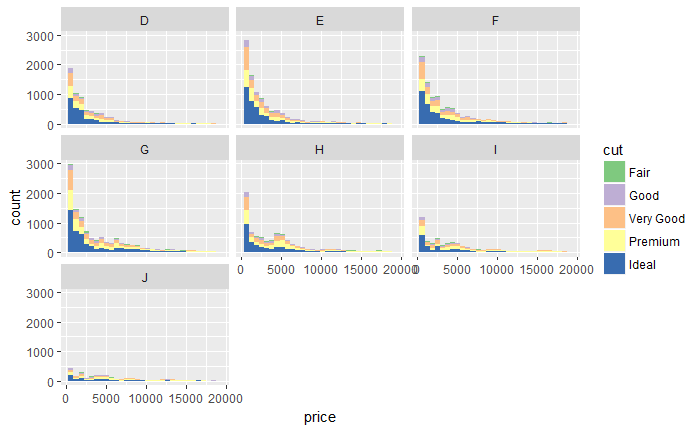

```r
ggplot(aes(x=price,fill=cut),data=diamonds)+
  geom_histogram()+
  facet_wrap(~color)+
  scale_fill_brewer(type = 'qual')
```

### 3. Create a scatterplot of diamond price vs.table and color the points by the cut of the diamond.

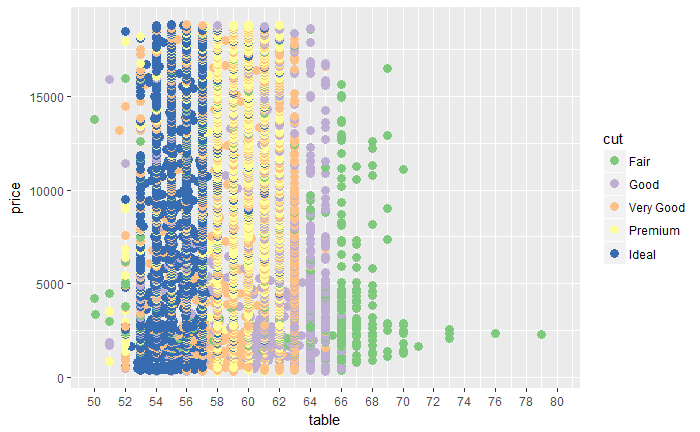

```r
ggplot(aes(x=table,y=price,color=cut),data=diamonds)+
  geom_point(size=3)+
  scale_x_continuous(limits = c(50,80),breaks =seq(50,80,2))+
  scale_color_brewer(type = 'qual')
```

### 4.What is the typical table range for majority of the diamonds of ideal cut?

Ans : 53 to 57

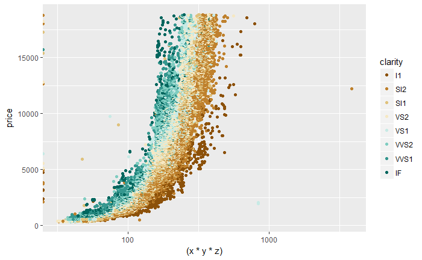

```r
ggplot(aes(y=price,x=(x*y*z),color=clarity),data=diamonds)+
  geom_point()+
  scale_x_log10()+
  scale_color_brewer(type = 'div')
```

### 7. Your task is to create a new variable called ‘prop_initiated’ in the Pseudo-Facebook data set. The variable should contain the proportion of friendships that the user initiated.

```r
pf$prop_initiated <- pf$friendships_initiated/pf$friend_count
```

### 8. Create a line graph of the median proportion of friendships initiated (‘prop_initiated’) vs.tenure and color the line segment by year_joined.bucket.

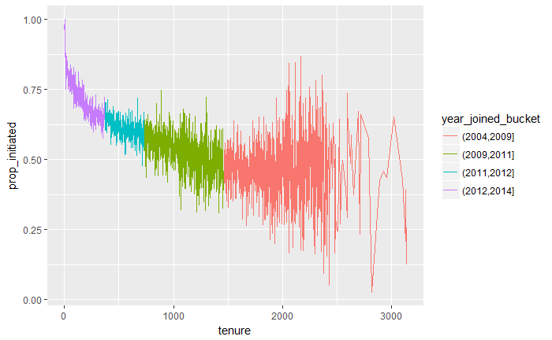

```r
ggplot(aes(x=tenure,y=prop_initiated),data=pf)+
  geom_line(aes(color=year_joined_bucket),stat='summary',fun.y=median)
```

### 9 . Smooth the last plot you created of prop_initiated vs tenure colored by year_joined.bucket. You can bin together ranges of tenure or add a smoother to the plot.

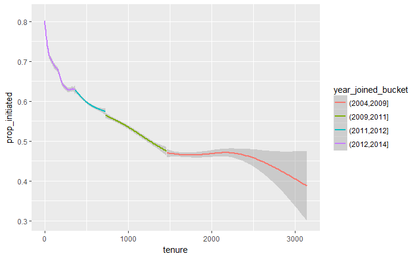

```r
ggplot(aes(x=tenure,y=prop_initiated),data=pf)+
  geom_smooth(aes(color=year_joined_bucket))
```

```r
with(subset(pf,!is.na(prop_initiated)),by(prop_initiated,year_joined_bucket,mean))
```

```
year_joined_bucket: (2004,2009]
[1] 0.4668151
------------------------------------------------------------------------------------------------------
year_joined_bucket: (2009,2011]
[1] 0.5301298
------------------------------------------------------------------------------------------------------
year_joined_bucket: (2011,2012]
[1] 0.5984577
------------------------------------------------------------------------------------------------------
year_joined_bucket: (2012,2014]
[1] 0.6653892
```

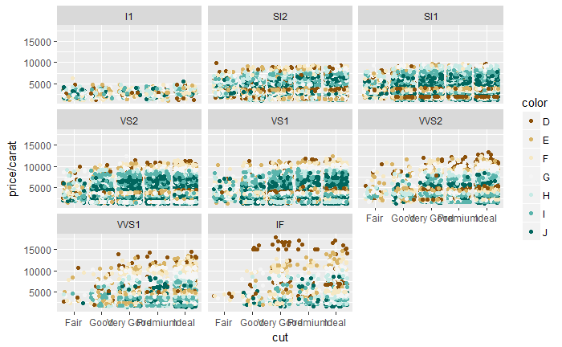

```r
ggplot(aes(x=cut,y=price/carat,color=color),data=diamonds)+
  geom_jitter()+
  facet_wrap(~clarity)+
  scale_color_brewer(type = 'div')
```